# Project 2: Heatwave analysis for Italy

ADJENIA Danélius; SABI DJESSOU Bana nadege; SODJINOU Hippolyte

Objective: We the examine consequences of the summer 2022 heatwave for Italy.\

This project is loosely based on Ballester et al. (2023) who conduct a quantitative analysis of the mortality-temperature relationship using the NUTS3 spatial resolution (both for mortality figures and ERA5 temperature scans). Below, we use mortality data for the whole of Italy, so results will differ from those of Ballester et al. (2023).\

• Ballester , J. et al. (2023). Heat-related mortality in Europe during the summer of 2022. Nature Medicine.

**Important: bolcks with “# Code in Python” are in Python**

```r
if(!require(tidyverse))install.packages("tidyverse")
if(!require(ISOweek))install.packages("ISOweek")
if(!require(lubridate))install.packages("lubridate")
if(!require(aweek))install.packages("aweek")
if(!require(glue))install.packages("glue")
if(!require(binsreg))install.packages("binsreg")
if(!require(reticulate)) install.packages("reticulate")
library(lubridate)  # for: day, year etc.
library(aweek)
library(tidyverse)
library(ISOweek)
library(glue)
library(binsreg)
library(reticulate)
```

```r
# If it is already configured, please restart R and remove "eval=FALSE, include=FALSE"
# The Python executable path
use_python("C:/Users/sodji/anaconda3/python.exe", required = TRUE)

# Check Python configuration
py_config()
```

```r
# For the first compilation, remove "eval=FALSE, include=FALSE"
py_install("cdsapi")
```

```python
# Code in Python
# Libraries for working with multidimensional arrays
import numpy as np
import xarray as xr

# Libraries for plotting and visualising data
import matplotlib.path as mpath
import matplotlib.pyplot as plt
import cartopy.crs as ccrs
from cartopy.mpl.gridliner import LONGITUDE_FORMATTER, LATITUDE_FORMATTER
import cartopy.feature as cfeature
import pandas as pd
# Disable warnings for data download via API
import urllib3

urllib3.disable_warnings()
```

## 1 Preliminaries: The temperature data for Italy

```python
# Code in Python
# Reading the file and extracting the information
with open ("C:/Users/sodji/OneDrive/Bureau/Datavis Traning/Datavis traning/Project Dataviz/Code/API_ERA5.txt", 'r') as f:
    lines = f.readlines()

# Initializing variables
URL = None
KEY = None

# Traversing each line to extract the URL and key
for line in lines:
    if line.startswith("url:"):
        URL = line.split(":", 1)[1].strip()
    elif line.startswith("key:"):
        KEY = line.split(":", 1)[1].strip()

# Verification of extraction
if URL is None or KEY is None:
    raise ValueError("The URL or key was not found in the file.")
```

```python
# Code in Python
DATADIR = 'C:/Users/sodji/OneDrive/Bureau/Datavis Traning/Datavis traning/Project Dataviz/Data/'
```

```python
# Code in Python
# For the first compilation, remove "eval=FALSE"
# CDS API
import cdsapi

## Get the Data

c = cdsapi.Client(url=URL, key=KEY)
c.retrieve(
    'reanalysis-era5-single-levels',
    {
        'product_type': 'reanalysis',
        'data_format': 'netcdf_legacy',
        'variable': '2m_temperature',
        'year': [
            '2015', '2016', '2017',
            '2018', '2019', '2020',
            '2021', '2022', '2023',
        ],
        'month': [
            '01', '02', '03',
            '04', '05', '06',
            '07', '08', '09',
            '10', '11', '12',
        ],
        'day': [
            '01', '02', '03',
            '04', '05', '06',
            '07', '08', '09',
            '10', '11', '12',
            '13', '14', '15',
            '16', '17', '18',
            '19', '20', '21',
            '22', '23', '24',
            '25', '26', '27',
            '28', '29', '30',
        ],
        'time': [
            '00:00', '01:00', '02:00',
            '03:00', '04:00', '05:00',
            '06:00', '07:00', '08:00',
            '09:00', '10:00', '11:00',
            '12:00', '13:00', '14:00',
            '15:00', '16:00', '17:00',
            '18:00', '19:00', '20:00',
            '21:00', '22:00', '23:00',
        ],
        'area': [46,9,37,18.5,],
    },
    f'{DATADIR}Italy_hourly.nc')
```

```python
# Code in Python
filename = DATADIR + "Italy_hourly.nc"
ds = xr.open_dataset(filename)

da = ds['t2m']      # surface temp. at 2 meters
t2m_C = da - 273.15 # convert from Kelvin to Celsius

del ds, da
```

```python
# Code in Python
t2m_C
```

```
<xarray.DataArray 't2m' (time: 77376, latitude: 37, longitude: 39)>
array([[[ -2.4244995,  -2.475708 ,  -2.7293396, ...,  -9.122467 ,
          -9.36795  , -11.370239 ],
        [ -1.4995728,  -1.4344177,  -1.6636047, ..., -14.138092 ,
         -14.909454 , -15.245697 ],
        [ -1.7648315,  -1.3366699,  -1.5658875, ..., -12.442963 ,
         -17.49347  , -17.833206 ],
        ...,
        [  6.2815857,   6.548004 ,   6.951721 , ...,  10.294312 ,
          10.159332 ,  10.030212 ],
        [  5.678894 ,   5.1902466,   5.532318 , ...,  10.530487 ,
          10.524658 ,  10.348999 ],
        [  3.4892883,   2.7644653,   2.6155396, ...,  10.055786 ,
          10.200073 ,  10.118622 ]],

       [[ -2.5932007,  -3.1807556,  -3.7787476, ..., -10.346405 ,
         -10.857178 , -12.291718 ],
        [ -1.7613525,  -1.9370117,  -2.2220764, ..., -13.389984 ,
         -14.310272 , -14.688416 ],
        [ -2.006836 ,  -1.7217712,  -2.006836 , ..., -12.698914 ,
         -16.210205 , -16.590637 ],
...
        [ 15.961456 ,  15.64035  ,  15.731079 , ...,  16.042908 ,
          16.126678 ,  16.172028 ],
        [ 15.33786  ,  14.217438 ,  13.867249 , ...,  16.134796 ,
          16.234863 ,  16.279083 ],
        [ 13.967316 ,  12.554871 ,  11.4496155, ...,  16.33841  ,
          16.448944 ,  16.411713 ]],

       [[  6.066345 ,   4.9436035,   2.851715 , ...,   3.5567932,
           3.7522278,   3.2054138],
        [  6.943573 ,   6.4944763,   6.2350464, ...,   2.492218 ,
           2.635315 ,   2.8284607],
        [  7.720764 ,   8.191956 ,   7.9313354, ...,   2.6213684,
           2.7249146,   2.9203796],
        ...,
        [ 15.918396 ,  15.650818 ,  15.738068 , ...,  15.978912 ,
          16.062683 ,  16.12085  ],
        [ 15.320404 ,  14.298889 ,  14.175568 , ...,  16.082458 ,
          16.181335 ,  16.230225 ],
        [ 12.293091 ,  11.697418 ,  11.591553 , ...,  16.298859 ,
          16.410553 ,  16.373322 ]]], dtype=float32)
Coordinates:
  * longitude  (longitude) float32 9.0 9.25 9.5 9.75 ... 17.75 18.0 18.25 18.5
  * latitude   (latitude) float32 46.0 45.75 45.5 45.25 ... 37.5 37.25 37.0
  * time       (time) datetime64[ns] 2015-01-01 ... 2023-12-30T23:00:00
```

```python
# Code in Python
# We start by resampling it into weekly data
t2m_weekly = t2m_C.resample(time="1W").mean()
```

```python
# Code in Python
t2m_weekly
```

```
<xarray.DataArray 't2m' (time: 470, latitude: 37, longitude: 39)>
array([[[ 4.1560874 ,  3.53884   ,  1.5340042 , ..., -1.1147426 ,
         -0.87090176, -0.86318207],
        [ 4.5672445 ,  4.431715  ,  3.9679718 , ..., -1.1286303 ,
         -1.1923275 , -1.404961  ],
        [ 4.140818  ,  4.226002  ,  3.7602122 , ..., -0.7633562 ,
         -1.2879988 , -1.5015755 ],
        ...,
        [13.596218  , 13.45688   , 13.482005  , ..., 13.191989  ,
         13.102633  , 13.028232  ],
        [13.08326   , 12.501472  , 12.659073  , ..., 13.159557  ,
         13.14841   , 13.083066  ],
        [11.49738   , 10.656945  , 10.751175  , ..., 13.137593  ,
         13.192048  , 13.120532  ]],

       [[ 5.8844357 ,  3.8618655 ,  0.5331103 , ...,  1.6669255 ,
          1.4498613 ,  1.3979125 ],
        [ 6.0166574 ,  5.1142473 ,  4.3945913 , ...,  2.1675465 ,
          1.915743  ,  1.6586622 ],
        [ 5.7246957 ,  5.610082  ,  4.8873878 , ...,  2.2345624 ,
          2.2849166 ,  2.0267892 ],
...
        [15.978569  , 15.928375  , 15.928999  , ..., 15.797011  ,
         15.800221  , 15.82845   ],
        [15.628354  , 15.483632  , 15.522932  , ..., 15.880537  ,
         15.898105  , 15.897542  ],
        [14.467939  , 14.104212  , 14.349861  , ..., 16.000565  ,
         16.019688  , 15.9828    ]],

       [[ 6.2470417 ,  5.816913  ,  4.1196117 , ...,  8.278544  ,
          8.02462   ,  7.8958697 ],
        [ 7.344949  ,  7.3452053 ,  7.1302743 , ...,  8.546401  ,
          8.257531  ,  8.035894  ],
        [ 7.950277  ,  8.328849  ,  8.1130085 , ...,  8.336593  ,
          8.306656  ,  8.083913  ],
        ...,
        [15.327776  , 15.0352955 , 15.080189  , ..., 15.94124   ,
         15.922514  , 15.93571   ],
        [14.329372  , 13.270748  , 13.136346  , ..., 16.032234  ,
         16.036139  , 16.027815  ],
        [12.130691  , 11.3942375 , 11.402867  , ..., 16.15986   ,
         16.195736  , 16.145636  ]]], dtype=float32)
Coordinates:
  * longitude  (longitude) float32 9.0 9.25 9.5 9.75 ... 17.75 18.0 18.25 18.5
  * latitude   (latitude) float32 46.0 45.75 45.5 45.25 ... 37.5 37.25 37.0
  * time       (time) datetime64[ns] 2015-01-04 2015-01-11 ... 2023-12-31
```

**Week corresponding to 03.08.2022**

```python
# Code in Python
# Set the date as a string (format day.month.year)
date_str = "03.08.2022"

# Convert the string to a datetime object by specifying the format
date = pd.to_datetime(date_str, format="%d.%m.%Y")

# Use isocalendar() to get the ISO week number
week_number = date.isocalendar().week

print(f"The date {date_str} corresponds to the week {week_number}.")
```

```
## The date 03.08.2022 corresponds to the week 31.
```

```python
# Code in Python
t2m_weekly_mean = t2m_weekly.groupby(t2m_weekly.time.dt.isocalendar().week).mean()
```

```python
# Code in Python
t2m_weekly_mean
```

```
<xarray.DataArray 't2m' (week: 53, latitude: 37, longitude: 39)>
array([[[ 3.2170436 ,  2.1112065 ,  0.3959197 , ...,  1.4339995 ,
          1.3702266 ,  1.3810073 ],
        [ 4.4258137 ,  3.9136684 ,  3.5077543 , ...,  1.5426805 ,
          1.5082899 ,  1.4735612 ],
        [ 4.3674297 ,  4.4574533 ,  4.0497108 , ...,  1.4703695 ,
          1.6293397 ,  1.5944301 ],
        ...,
        [14.779855  , 14.5590515 , 14.496021  , ..., 14.125826  ,
         14.090406  , 14.086544  ],
        [14.218553  , 13.501381  , 13.366755  , ..., 14.201115  ,
         14.232324  , 14.225725  ],
        [12.403564  , 11.638462  , 11.672289  , ..., 14.305561  ,
         14.362494  , 14.326283  ]],

       [[ 3.1726959 ,  1.7270422 , -0.49123764, ...,  0.9204286 ,
          0.7924449 ,  0.8220234 ],
        [ 4.320559  ,  3.5763478 ,  3.0578465 , ...,  1.1400986 ,
          1.1061436 ,  1.0822221 ],
        [ 4.1003566 ,  4.1695704 ,  3.648764  , ...,  1.0788354 ,
          1.3868753 ,  1.3628243 ],
...
        [15.553497  , 15.300077  , 15.259881  , ..., 15.172431  ,
         15.139452  , 15.129327  ],
        [14.805537  , 13.954212  , 13.793619  , ..., 15.202898  ,
         15.242911  , 15.239221  ],
        [12.724604  , 11.996379  , 12.1005    , ..., 15.28636   ,
         15.352672  , 15.318235  ]],

       [[ 2.2633023 ,  1.4254408 , -0.01691157, ...,  1.9454362 ,
          1.7944505 ,  1.8968064 ],
        [ 2.6756773 ,  2.3252044 ,  2.225043  , ...,  2.1499715 ,
          2.1088548 ,  2.241623  ],
        [ 2.0748177 ,  2.295536  ,  2.195     , ...,  1.7472146 ,
          2.194019  ,  2.327407  ],
        ...,
        [14.841211  , 14.519865  , 14.423643  , ..., 15.1970825 ,
         15.171005  , 15.175755  ],
        [14.11294   , 13.441463  , 13.301694  , ..., 15.297506  ,
         15.346033  , 15.340969  ],
        [12.242144  , 11.367762  , 11.231596  , ..., 15.413422  ,
         15.464966  , 15.429668  ]]], dtype=float32)
Coordinates:
  * longitude  (longitude) float32 9.0 9.25 9.5 9.75 ... 17.75 18.0 18.25 18.5
  * latitude   (latitude) float32 46.0 45.75 45.5 45.25 ... 37.5 37.25 37.0
  * week       (week) int64 1 2 3 4 5 6 7 8 9 10 ... 45 46 47 48 49 50 51 52 53
```

```python
# Code in Python
print(f"Minimal longitude: {t2m_weekly_mean.longitude.min()}")
```

```
## Minimal longitude: <xarray.DataArray 'longitude' ()>
## array(9.)
```

```python
print(f"Maximal longitude: {t2m_weekly_mean.longitude.max()}")
```

```
## Maximal longitude: <xarray.DataArray 'longitude' ()>
## array(18.5)
```

```python
print(f"Minimal latitude: {t2m_weekly_mean.latitude.min()}")
```

```
## Minimal latitude: <xarray.DataArray 'latitude' ()>
## array(37.)
```

```python
print(f"Maximal latitude: {t2m_weekly_mean.latitude.max()}")
```

```
## Maximal latitude: <xarray.DataArray 'latitude' ()>
## array(46.)
```

```python
# Code in Python
fig_dir = 'C:/Users/sodji/OneDrive/Bureau/Datavis Traning/Datavis traning/Project Dataviz/'
```

[figure not shown]

```python
# Code in Python
keep_week = 31
fig, ax = plt.subplots(1, 1, figsize = (10, 4), subplot_kw={'projection': ccrs.PlateCarree()})
im = plt.pcolormesh(t2m_weekly_mean.longitude,
                    t2m_weekly_mean.latitude,
                    t2m_weekly_mean.sel(week = keep_week),
                    cmap='RdBu_r',
                    vmin=t2m_weekly_mean.sel(week = keep_week).min(),
                    vmax=t2m_weekly_mean.sel(week = keep_week).max() )
ax.set_title('Mean temperatures on 03.08.2022', fontsize=16)
ax.gridlines(draw_labels=True, linewidth=1, color='gray', alpha=0.5, linestyle='--')
ax.coastlines(color='black')
ax.set_extent([9,18.5,37,46], crs=ccrs.PlateCarree())
cbar = plt.colorbar(im,fraction=0.05, pad=0.04)
cbar.set_label('temperature (°C)')

fig.tight_layout()
fig.savefig(f"{fig_dir}Output/map_Italy_August2022.png", bbox_inches='tight')
plt.show()
```

```python
# Code in Python
# aggregate local measures
weights = np.cos(np.deg2rad(t2m_weekly))
weights = weights.fillna(0)
weights.name = "weights"
t2m_weekly_mean_weighted = t2m_weekly.weighted(weights)
Italy_t2m = t2m_weekly_mean_weighted.mean(["longitude", "latitude"])
```

```python
# Code in Python
Italy_t2m
```

```
<xarray.DataArray 't2m' (time: 470)>
array([ 8.293744 ,  9.459037 , 10.604056 ,  9.46723  ,  7.5819364,
        7.4900455,  7.976827 ,  9.010192 ,  9.728655 ,  9.851538 ,
        9.651535 , 11.092066 , 12.316626 , 11.866973 , 11.225739 ,
       14.437986 , 14.96348  , 15.526722 , 19.014713 , 18.825851 ,
       17.396107 , 17.172956 , 21.699594 , 22.70024  , 20.834154 ,
       21.474571 , 24.22245  , 25.587225 , 26.866423 , 27.137634 ,
       25.77346  , 26.883196 , 25.345001 , 22.894314 , 24.575655 ,
       24.115978 , 20.922533 , 23.890284 , 19.431189 , 18.354723 ,
       18.911882 , 17.561998 , 15.5267105, 15.721374 , 15.340992 ,
       15.288065 , 14.160986 ,  9.966918 , 11.700415 , 10.608385 ,
       10.476739 , 10.977096 ,  9.306811 , 11.093461 ,  9.821567 ,
        6.3366256, 10.512316 , 10.7086525, 11.476654 , 11.214745 ,
       11.556714 , 10.470979 ,  9.810915 , 10.728783 , 11.610145 ,
       14.125638 , 14.678492 , 15.7718315, 15.080904 , 13.383145 ,
       15.171939 , 16.634277 , 16.507017 , 18.767094 , 18.844332 ,
       20.30687  , 21.086502 , 22.81366  , 23.617306 , 24.728756 ,
       23.585238 , 24.504759 , 24.566996 , 24.370705 , 22.699038 ,
       23.725101 , 23.514217 , 23.810846 , 22.17321  , 22.079737 ,
       19.509386 , 19.69564  , 17.469894 , 16.808271 , 16.734854 ,
       17.101244 , 15.94573  , 12.696496 , 13.14277  , 14.825947 ,
...
        7.6440325, 10.702542 , 11.369128 , 11.279225 , 12.084827 ,
       13.23835  , 13.245415 , 15.003625 , 15.55994  , 18.200329 ,
       20.020145 , 21.18557  , 22.894306 , 22.342709 , 23.44945  ,
       24.989677 , 26.295267 , 25.155058 , 24.885447 , 26.933157 ,
       26.717184 , 26.958395 , 24.97445  , 25.560133 , 24.403482 ,
       23.673084 , 24.376871 , 22.662663 , 19.038076 , 19.770668 ,
       19.171082 , 18.685825 , 18.981276 , 19.044868 , 16.835701 ,
       15.477961 , 15.028224 , 12.558386 , 11.318348 , 12.828429 ,
       11.645973 , 11.861665 , 12.847586 , 12.07186  , 10.916684 ,
        9.020314 ,  7.6897516,  8.761023 ,  5.9319677, 10.056386 ,
       11.560832 ,  9.464328 , 12.634913 , 11.58815  , 13.364689 ,
       12.35039  , 10.3472185, 12.60007  , 13.991676 , 15.142256 ,
       16.265583 , 16.053356 , 16.342882 , 19.030794 , 19.882233 ,
       20.586807 , 21.283604 , 24.037998 , 23.264338 , 24.34499  ,
       26.637161 , 27.876192 , 25.766907 , 24.366762 , 23.214851 ,
       25.465153 , 27.208931 , 22.93155  , 23.363342 , 23.310974 ,
       22.882391 , 21.211903 , 21.052248 , 21.089449 , 19.686539 ,
       19.740656 , 17.840801 , 15.348887 , 15.241174 , 12.6546955,
       12.890453 ,  9.902756 , 11.766744 , 11.524636 , 11.878176 ],
      dtype=float32)
Coordinates:
  * time     (time) datetime64[ns] 2015-01-04 2015-01-11 ... 2023-12-31
```

```python
# Code in Python
df = Italy_t2m.to_dataframe()
df = df.reset_index()  # convert multi-index to variable
# this works since the index values are unique (or call reset_index()) !!
df['week'] = df['time'].dt.isocalendar().week
df['year'] = df['time'].dt.year
# Drop the column 'time'
df.drop('time', axis=1, inplace=True)
df = df[['year', 'week', 't2m']]
df_sorted = df.sort_values(by=["year", "week"], ascending=[True, True])
df_sorted.to_csv(DATADIR+"Italy_week_temperature.csv", index=False)
```

```python
# Code in Python
df_sorted
```

```
##      year  week        t2m
## 0    2015     1   8.293744
## 1    2015     2   9.459037
## 2    2015     3  10.604056
## 3    2015     4   9.467230
## 4    2015     5   7.581936
## ..    ...   ...        ...
## 466  2023    49   9.902756
## 467  2023    50  11.766744
## 468  2023    51  11.524636
## 417  2023    52  12.847586
## 469  2023    52  11.878176
##
## [470 rows x 3 columns]
```

Loading the csv-file of the temperature data, and visualise the temperature data

```r
Data_dir = "C:/Users/sodji/OneDrive/Bureau/Datavis Traning/Datavis traning/Project Dataviz/"

Italy_week_temperature <- read_csv(paste0(Data_dir,"Data/Italy_week_temperature.csv"))
glimpse(Italy_week_temperature)
```

```
## Rows: 470
## Columns: 3
## $ year <dbl> 2015, 2015, 2015, 2015, 2015, 2015, 2015, 2015, 2015, 2015, 2015,…
## $ week <dbl> 1, 2, 3, 4, 5, 6, 7, 8, 9, 10, 11, 12, 13, 14, 15, 16, 17, 18, 19…
## $ t2m  <dbl> 8.293744, 9.459037, 10.604056, 9.467230, 7.581936, 7.490045, 7.97…
```

**Identify the weeks correspond to the start date and the end date for the summer in 2022.**

```python
# Code in Python
# Set the date as a string (format day.month.year)
date_str1 = "01.06.2022"
date_str2 = "31.08.2022"

# Convert the string to a datetime object by specifying the format
date1 = pd.to_datetime(date_str1, format="%d.%m.%Y")
date2 = pd.to_datetime(date_str2, format="%d.%m.%Y")

# Use isocalendar() to get the ISO week number
week_number1 = date1.isocalendar().week
week_number2 = date2.isocalendar().week


print(f"The date {date_str1} correspond to the week {week_number1}.")
```

```
## The date 01.06.2022 correspond to the week 22.
```

```python
print(f"The date {date_str2} correspond to the week {week_number2}.")
```

```
## The date 31.08.2022 correspond to the week 35.
```

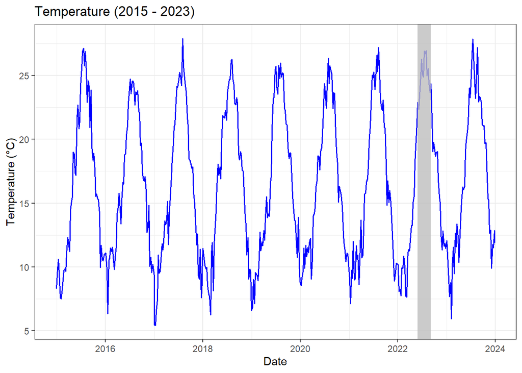

```r
#  Create a date column from year and week
Italy_week_temperature_all <- Italy_week_temperature %>%
  mutate(
    date = ISOweek2date(
      sprintf("%4d-W%02d-1", year, week)  # ex : "2022-W03-1"
    )
  )

# Define the start/end of summer 2022 (example: weeks 22 to 35)
#    To add a highlight to the figure
summer_2022_start <- ISOweek2date("2022-W22-1")  # week 22
summer_2022_end   <- ISOweek2date("2022-W35-7")  # week 35

#  Plot the full time series and highlight summer 2022
ggplot(Italy_week_temperature_all, aes(x = date, y = t2m)) +
  # Curve
  geom_line(color = "blue", size = 0.7) +
  # Greyed out band for summer 2022
  annotate(
    "rect",
    xmin = summer_2022_start,
    xmax = summer_2022_end,
    ymin = -Inf, ymax = Inf,
    fill = "gray",
    alpha = 0.8
  ) +
  labs(
    title = "Temperature (2015 - 2023)",
    x = "Date",
    y = "Temperature (°C)"
  ) +
  theme_bw()
```

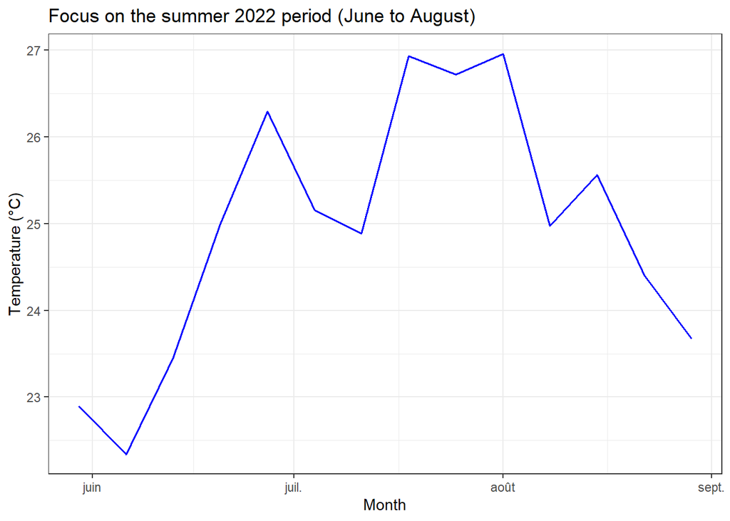

```r
# Filter to keep only Summer 2022 (weeks 22 to 35)
Italy_summer_2022 <- Italy_week_temperature %>%
  filter(year == '2022', week >= 22, week <= 35)


Italy_summer_2022 <- Italy_summer_2022 %>%
  mutate(
    # Creates the string in the format "YYYY-Www-1"
    iso_str = sprintf("%s-W%02d-1", year, week),
    date = ISOweek2date(iso_str)
  )

# Visualize the time series for summer 2022
ggplot(Italy_summer_2022, aes(x = date, y = t2m)) +
  geom_line(color = "blue", size = 0.7) +
  labs(
    title = "Focus on the summer 2022 period (June to August)",
    x = "Month",
    y = "Temperature (°C)"
  ) +
  theme_bw()
```

## 2 The mortality data

```r
word_mortality <- read_csv(paste0(Data_dir,"Data/world_mortality.csv"))
glimpse(word_mortality)
```

```
## Rows: 33,890
## Columns: 6
## $ iso3c        <chr> "ALB", "ALB", "ALB", "ALB", "ALB", "ALB", "ALB", "ALB", "…
## $ country_name <chr> "Albania", "Albania", "Albania", "Albania", "Albania", "A…
## $ year         <dbl> 2015, 2015, 2015, 2015, 2015, 2015, 2015, 2015, 2015, 201…
## $ time         <dbl> 1, 2, 3, 4, 5, 6, 7, 8, 9, 10, 11, 12, 1, 2, 3, 4, 5, 6, …
## $ time_unit    <chr> "monthly", "monthly", "monthly", "monthly", "monthly", "m…
## $ deaths       <dbl> 2490, 2139, 2051, 1906, 1709, 1561, 2008, 1687, 1569, 156…
```

```r
# Function of converting a combination of year and period number (week or month) to actual date
# Defining the get_date() function using ISOweek2date()
get_date <- function(week, year) {
    # Create a string in the format "YYYY-Www-1"
    iso_str <- sprintf("%d-W%02d-1", year, week)
    # Convert string to date
    ISOweek2date(iso_str)}

country <- "Italy"   ## iso3c == "ITA"

word_mortality %>%
   filter(iso3c == "ITA") %>%
   select(-c(iso3c,country_name,time_unit)) %>%
   rename(mortality=deaths, week=time) %>%
   mutate(start_date = get_date(week=week,year=year)) ->
   mortality

glimpse(mortality)
```

```
## Rows: 522
## Columns: 4
## $ year       <dbl> 2015, 2015, 2015, 2015, 2015, 2015, 2015, 2015, 2015, 2015,…
## $ week       <dbl> 1, 2, 3, 4, 5, 6, 7, 8, 9, 10, 11, 12, 13, 14, 15, 16, 17, …
## $ mortality  <dbl> 15178, 15811, 15480, 14922, 15228, 15640, 15510, 15149, 145…
## $ start_date <date> 2014-12-29, 2015-01-05, 2015-01-12, 2015-01-19, 2015-01-26…
```

## 3 A simple time-series model of excess mortality

```r
#  Filter data up to March 1, 2020
mortality_ref <- mortality %>%
  filter(start_date < as.Date("2020-03-01"))

# Building a linear model
#    - factor(week) to have a fixed effect (a "dummification" of the week)
#    - year as numeric (for a linear trend) or factor(year) (for a fixed effect per year)
mod <- lm(mortality ~ factor(week) + year, data = mortality_ref)

# Check a model summary
summary(mod)
```

```
##
## Call:
## lm(formula = mortality ~ factor(week) + year, data = mortality_ref)
##
## Residuals:
##     Min      1Q  Median      3Q     Max
## -2467.1  -389.5   -29.8   282.3  3522.6
##
## Coefficients:
##                 Estimate Std. Error t value Pr(>|t|)
## (Intercept)    125581.93   66978.54   1.875 0.062148 .
## factor(week)2     329.50     464.58   0.709 0.478938
## factor(week)3     157.17     464.58   0.338 0.735467
## factor(week)4    -303.17     464.58  -0.653 0.514733
## factor(week)5    -405.50     464.58  -0.873 0.383724
## factor(week)6    -860.83     464.58  -1.853 0.065256 .
## factor(week)7    -978.17     464.58  -2.105 0.036404 *
## factor(week)8   -1259.67     464.58  -2.711 0.007239 **
## factor(week)9   -1248.67     464.58  -2.688 0.007754 **
## factor(week)10  -1538.48     487.54  -3.156 0.001830 **
## factor(week)11  -1904.68     487.54  -3.907 0.000125 ***
## factor(week)12  -2407.08     487.54  -4.937 1.58e-06 ***
## factor(week)13  -2451.88     487.54  -5.029 1.03e-06 ***
## factor(week)14  -2720.08     487.54  -5.579 7.19e-08 ***
## factor(week)15  -2945.08     487.54  -6.041 6.63e-09 ***
## factor(week)16  -3135.48     487.54  -6.431 8.01e-10 ***
## factor(week)17  -3322.88     487.54  -6.816 9.22e-11 ***
## factor(week)18  -3503.28     487.54  -7.186 1.07e-11 ***
## factor(week)19  -3500.48     487.54  -7.180 1.11e-11 ***
## factor(week)20  -3835.48     487.54  -7.867 1.72e-13 ***
## factor(week)21  -3727.28     487.54  -7.645 6.77e-13 ***
## factor(week)22  -3955.68     487.54  -8.114 3.68e-14 ***
## factor(week)23  -3692.88     487.54  -7.575 1.04e-12 ***
## factor(week)24  -3781.88     487.54  -7.757 3.40e-13 ***
## factor(week)25  -3915.68     487.54  -8.032 6.17e-14 ***
## factor(week)26  -3850.68     487.54  -7.898 1.42e-13 ***
## factor(week)27  -3587.48     487.54  -7.358 3.84e-12 ***
## factor(week)28  -3344.08     487.54  -6.859 7.19e-11 ***
## factor(week)29  -3580.08     487.54  -7.343 4.20e-12 ***
## factor(week)30  -3169.08     487.54  -6.500 5.47e-10 ***
```

[output cut: 15 more lines]

```
## factor(week)46  -3034.08     487.54  -6.223 2.50e-09 ***
## factor(week)47  -2987.28     487.54  -6.127 4.18e-09 ***
## factor(week)48  -2955.28     487.54  -6.062 5.94e-09 ***
## factor(week)49  -2591.68     487.54  -5.316 2.64e-07 ***
## factor(week)50  -2188.48     487.54  -4.489 1.16e-05 ***
## factor(week)51  -1722.28     487.54  -3.533 0.000503 ***
## factor(week)52  -1172.08     487.54  -2.404 0.017057 *
## factor(week)53  -2029.39     873.10  -2.324 0.021036 *
## year              -54.76      33.20  -1.649 0.100524
## ---
## Signif. codes:  0 '***' 0.001 '**' 0.01 '*' 0.05 '.' 0.1 ' ' 1
##
## Residual standard error: 804.7 on 216 degrees of freedom
## Multiple R-squared:  0.7679, Adjusted R-squared:  0.711
## F-statistic: 13.48 on 53 and 216 DF,  p-value: < 2.2e-16
```

### Predicting for the summer of 2022 and calculating excess mortality

```r
# Extract mortality for the summer of 2022 (dates to be adapted according to the desired period)
mortality_2022 <- mortality %>%
  filter(year == 2022,
         start_date >= as.Date("2022-06-01"),
         start_date <= as.Date("2022-08-31"))  # for example until the end of September

# Apply your linear model prediction
mortality_2022 <- mortality_2022 %>%
  mutate(predicted = predict(mod, newdata = mortality_2022),
         excess    = mortality - predicted)  # excess mortality
```

**predicted** : the mortality predicted by your model.

**excess** : the observed difference – predicted. A positive value indicates more deaths than the model would have predicted, and therefore potentially excess mortality.

**Visualisation**

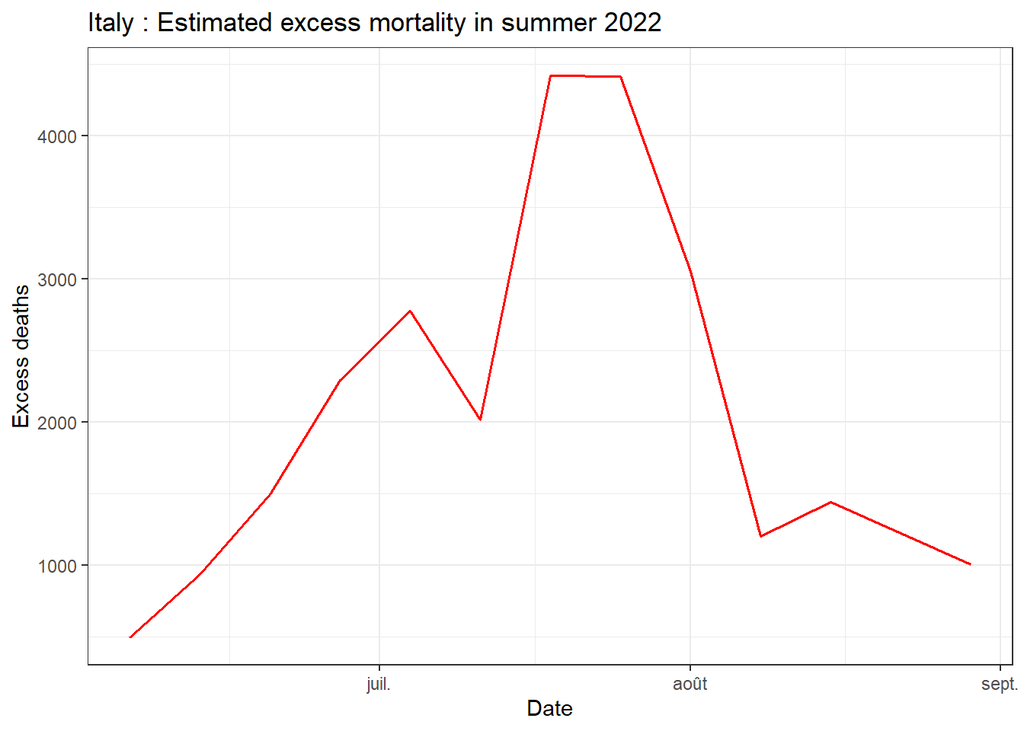

```r
ggplot(mortality_2022, aes(x = start_date, y = excess)) +
  geom_line(color = "red", size = 0.7) +
  labs(
    title    = "Italy : Estimated excess mortality in summer 2022",
    x        = "Date",
    y        = "Excess deaths"
  ) +
  theme_bw()
```

```r
total_excess_deaths = sum(mortality_2022$excess)
print(glue("Total number of excess deaths in Italy in summer of 2022: {total_excess_deaths}"))
```

```
## Total number of excess deaths in Italy in summer of 2022: 26782.978723404
```

## 4 The mortality and temperature relationship

```r
glimpse(Italy_week_temperature)
```

```
## Rows: 470
## Columns: 3
## $ year <dbl> 2015, 2015, 2015, 2015, 2015, 2015, 2015, 2015, 2015, 2015, 2015,…
## $ week <dbl> 1, 2, 3, 4, 5, 6, 7, 8, 9, 10, 11, 12, 13, 14, 15, 16, 17, 18, 19…
## $ t2m  <dbl> 8.293744, 9.459037, 10.604056, 9.467230, 7.581936, 7.490045, 7.97…
```

```r
glimpse(mortality)
```

```
## Rows: 522
## Columns: 4
## $ year       <dbl> 2015, 2015, 2015, 2015, 2015, 2015, 2015, 2015, 2015, 2015,…
## $ week       <dbl> 1, 2, 3, 4, 5, 6, 7, 8, 9, 10, 11, 12, 13, 14, 15, 16, 17, …
## $ mortality  <dbl> 15178, 15811, 15480, 14922, 15228, 15640, 15510, 15149, 145…
## $ start_date <date> 2014-12-29, 2015-01-05, 2015-01-12, 2015-01-19, 2015-01-26…
```

```r
mortality %>%
    left_join(Italy_week_temperature, by=c("year", "week")) ->
    mortality_Italy

glimpse(mortality_Italy)
```

```
## Rows: 524
## Columns: 5
## $ year       <dbl> 2015, 2015, 2015, 2015, 2015, 2015, 2015, 2015, 2015, 2015,…
## $ week       <dbl> 1, 2, 3, 4, 5, 6, 7, 8, 9, 10, 11, 12, 13, 14, 15, 16, 17, …
## $ mortality  <dbl> 15178, 15811, 15480, 14922, 15228, 15640, 15510, 15149, 145…
## $ start_date <date> 2014-12-29, 2015-01-05, 2015-01-12, 2015-01-19, 2015-01-26…
## $ t2m        <dbl> 8.293744, 9.459037, 10.604056, 9.467230, 7.581936, 7.490045…
```

```r
est2 <- binsreg(mortality,t2m, data=data.frame(mortality_Italy), nbins=10, line=c(1,0))
```

[figure not shown]

```r
#est2$bins_plot
```

## Session Information

```r
if (!require(sessioninfo)) install.packages("sessioninfo")
library(sessioninfo)
```

```r
platform_info()
```

```
##  setting  value
##  version  R version 4.4.1 (2024-06-14 ucrt)
##  os       Windows 11 x64 (build 26100)
##  system   x86_64, mingw32
##  ui       RTerm
##  language (EN)
##  collate  French_France.utf8
##  ctype    French_France.utf8
##  tz       Europe/Paris
##  date     2025-04-09
##  pandoc   3.6.4 @ C:/PROGRA~1/Pandoc/ (via rmarkdown)
```